# Sound Classification Example

**Toni Heittola**  
toni.heittola@tuni.fi

# Introduction

This presentation goes through basic steps to build a **CNN**-based sound classifier.

## Outline

- Dataset
- Cross-validation set
- Acoustic features
- Learning the acoustic model
- Testing the learned model
- Evaluation

## Application – Acoustic scene classification

*The goal of acoustic scene classification is to classify a test recording into one of the predefined ten acoustic scene classes*

[figure not shown]

## Key tools used in this example:

- **`dcase_util`** – used to ease data handling, https://github.com/DCASE-REPO/dcase_util
- **`keras`** – neural network API for fast experimentation used on top of **`tensorflow`** machine learning framework
- **`scikit-learn`** – set of machine learning tools, here used to evaluate the system output

# Dataset

**TUT Urban Acoustic Scenes 2018** development dataset is used in this example:

- The dataset was used as a development dataset in [acoustic scene classfication task](https://dcase.community/challenge2018/task-acoustic-scene-classification#subtask-a) (task1A) in the DCASE2018 Challenge
- Recordings from 10 scene classes, 6 large European cities
- 5-6 minute recordings around selected locations, which were split into **10 second audio segments**
- 8640 segments in total (24h)

Dataset can be downloaded and accessed easily by using **dataset handler class** from `dcase_util`:

```python
db = dcase_util.datasets.TUTUrbanAcousticScenes_2018_DevelopmentSet(
    data_path=dataset_storage_path
).initialize()
```

```
Audio file count : 8640
Scene class count: 10
```

Basic statistics of the dataset:

```
MetaDataContainer :: Class
Items                               : 8640
Unique
  Files                             : 8640
  Scene labels                      : 10
  Event labels                      : 0
  Tags                              : 0
  Identifiers                       : 286
  Datasets                          : 0
  Source labels                     : 1

Scene statistics
  Scene label             Count   Identifiers
  --------------------   ------   -----------
  airport                   864            22
  bus                       864            36
  metro                     864            29
  metro_station             864            40
  park                      864            25
  public_square             864            24
  shopping_mall             864            22
  street_pedestrian         864            28
  street_traffic            864            25
  tram                      864            35
```

## Important aspects

- We need to be aware of the **recording location** of each segment
- Audio segments from the same location around the same time are **highly correlated**
- Unrealistic to be able to train the system and test it with material recorded **in the same location only a few minutes apart**
- The cross-validation set should take this into account to give **realistic performance estimates**

# Cross-validation set

- Dataset is released with a single **train/test**-split
- We need also a **validation set** to follow system performance on **unseen data** during the training process
- Dataset class from `dcase_util` can be used to split the original training set into a new training set and validation set (70/30 split done according to recording locations)

## Train/Test split bundled with the dataset

| Scene label | Train (locations) | Test (locations) | Split % | Train set (items) | Test set (items) | Split % |
| --- | --- | --- | --- | --- | --- | --- |
| airport | 15 | 7 | 68 | 599 | 265 | 69 |
| bus | 26 | 10 | 72 | 622 | 242 | 71 |
| metro | 20 | 9 | 68 | 603 | 261 | 69 |
| metro_station | 28 | 12 | 70 | 605 | 259 | 70 |
| park | 18 | 7 | 72 | 622 | 242 | 71 |
| public_square | 18 | 6 | 75 | 648 | 216 | 75 |
| shopping_mall | 16 | 6 | 72 | 585 | 279 | 67 |
| street_pedestrian | 20 | 8 | 71 | 617 | 247 | 71 |
| street_traffic | 18 | 7 | 72 | 618 | 246 | 71 |
| tram | 24 | 11 | 68 | 603 | 261 | 69 |
| Overall | 203 | 83 | 70 | 6122 | 2518 | 70 |

## Generating validation set

```python
training_files, validation_files = db.validation_split(
    validation_amount=0.3, # split target 30%
    fold=1, # cross-validation fold id
    # balance based on scenes and locations
    balancing_mode='identifier_two_level_hierarchy',
    disable_progress_bar=True
)

train_meta = db.train(1).filter(file_list=training_files)
validation_meta = db.train(1).filter(file_list=validation_files)
```

```
Training items  : 4134
Validation items: 1988
```

## Train / Validation statistics

| Scene label | Train (locations) | Validation (locations) | Split % | Train set (items) | Validation set (items) | Split % |
| --- | --- | --- | --- | --- | --- | --- |
| airport | 9 | 6 | 40 | 411 | 188 | 31 |
| bus | 16 | 10 | 38 | 413 | 209 | 33 |
| metro | 13 | 7 | 35 | 422 | 181 | 30 |
| metro_station | 18 | 10 | 35 | 408 | 197 | 32 |
| park | 12 | 6 | 33 | 425 | 197 | 31 |
| public_square | 12 | 6 | 33 | 433 | 215 | 33 |
| shopping_mall | 10 | 6 | 37 | 360 | 225 | 38 |
| street_pedestrian | 13 | 7 | 35 | 422 | 195 | 31 |
| street_traffic | 12 | 6 | 33 | 425 | 193 | 31 |
| tram | 16 | 8 | 33 | 415 | 188 | 31 |
| Overall | 131 | 72 | 35 | 4134 | 1988 | 32 |

# Features – log-mel energies

Feature extractor initialized with parameters and used to extract features:

```python
# Load audio
audio = dcase_util.containers.AudioContainer().load(
    filename=db.audio_files[0], mono=True
)

# Create feature extractor
mel_extractor = dcase_util.features.MelExtractor(
    n_mels=40,
    win_length_seconds=0.04,
    hop_length_seconds=0.02,
    fs=audio.fs
)

# Extract features
mel_data = mel_extractor.extract(y=audio)
```

## Feature matrix

```
mel_data shape (frequency, time):
 (40, 501)
```

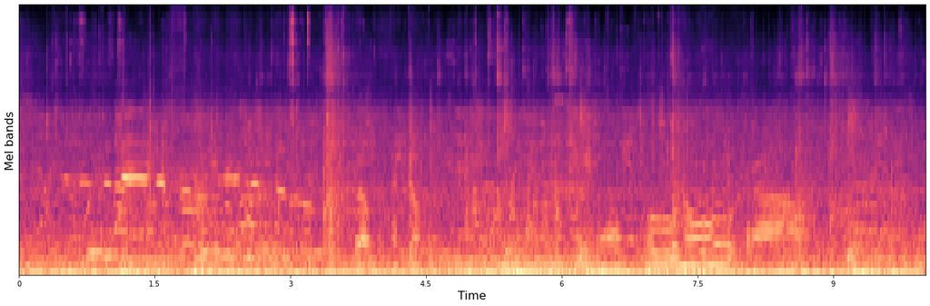

# Learning examples

1) **Feature matrix**

```python
# Load audio
audio = dcase_util.containers.AudioContainer().load(
    filename=train_meta[0].filename, mono=True
)

# Extract log-mel energies
sequence_length = 500        # 10s / 0.02s = 500
mel_extractor = dcase_util.features.MelExtractor(
    n_mels=40, win_length_seconds=0.04, hop_length_seconds=0.02, fs=audio.fs
)

features = mel_extractor.extract(audio.data)[:,:sequence_length]
```

```
features shape (frequency, time):
 (40, 500)
```

2) **Target vector** (one-hot encoded vector)

```python
# List of scene labels
scene_labels = db.scene_labels()

# Empty target vector
target_vector = numpy.zeros(len(scene_labels))

# Place one at correct position
target_vector[scene_labels.index(train_meta[0].scene_label)] = 1
```

```
array([1., 0., 0., 0., 0., 0., 0., 0., 0., 0.])
```

```
target vector shape (classes, ):
 (10,)
```

# Learning data

All learning data is collected into `X_train` and `Y_train` matrices:

```
X_train shape (sequence, frequence, time):
 (4134, 40, 500)
Y_train shape (sequence, classes):
 (4134, 10)
```

Matrix data:

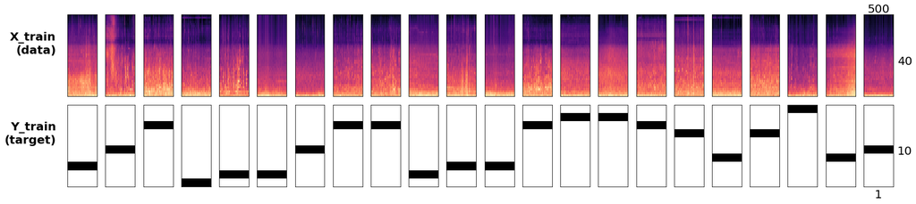

# Neural network structure

Neural network consists of two CNN blocks, the pooling layer, and the output layer.

Next, we create a neural network structure layer by layer.

**Input** layer:

```python
input_layer = Input(
    shape=(feature_vector_length, sequence_length),
    name='Input'
)
```

**Reshaping** layer to add channel axis into input data:

```python
x = Reshape(
    target_shape=(feature_vector_length, sequence_length, 1),
    name='Input_Reshape'
)(input_layer)
```

```
Output shape (sequence, frequency, time, channel):
 (None, 40, 500, 1)
```

Two convolutional **layer groups** consisting of:

1) **Convolution** to capture context and extract high-level features:  
*kernel 5x5 and filters 64*

```python
x = Conv2D(
    filters=64,
    kernel_size=(5, 5),
    activation='linear',
    padding='same',
    data_format='channels_last',
    name='Conv1'
)(x)
```

2) **Batch normalization** to enable higher learning rates

```python
x = BatchNormalization(
    axis=-1,
    name='Conv1_BatchNorm'
)(x)
```

3) **Activation** (ReLu) to introduce non-linearity

```python
x = Activation(
    activation='relu', name='Conv1_Activation'
)(x)
```

4) **Pooling** (2D) to extract dominant features

```python
x = MaxPooling2D(
    pool_size=(2, 4), name='Conv1_Pooling'
)(x)
```

5) **Dropout** to avoid overfitting

```python
x = Dropout(
    rate=0.2, name='Conv1_DropOut'
)(x)
```

```
Output shape of CNN layer group 1 (sequence, frequency, time, feature):
 (None, 20, 125, 64)
```

Second convolutional layer group:

```python
x = Conv2D(filters=64, kernel_size=(5, 5), activation='linear', padding='same', data_format='channels_last', name='Conv2')(x)
x = BatchNormalization(axis=-1, name='Conv2_BatchNorm')(x)
x = Activation(activation='relu', name='Conv2_Activation')(x)
x = MaxPooling2D(pool_size=(2, 2), name='Conv2_Pooling')(x)
x = Dropout(rate=0.2, name='Conv2_DropOut')(x)
```

```
Output shape of CNN layer group 2 (sequence, frequency, time, feature):
 (None, 10, 62, 64)
```

**Global max pooling** is applied to the output of the last convolutional layer group to summarize output into a **single vector**:

```python
x = GlobalMaxPooling2D(
    data_format='channels_last',
    name='GlobalPooling'
)(x)
```

```
Output shape (sequence, feature):
 (None, 64)
```

**Output layer** as fully-connected layer with a softmax activation:

```python
output_layer = Dense(
    units=len(db.scene_labels()),
    activation='softmax',
    name='Output'
)(x)
```

```
Output shape (sequence, class):
 (None, 10)
```

# Training

Key parameters:

- **Loss** – function used to measure the difference between target and prediction  
  `categorical_crossentropy`
- **Metric** – evaluated for training and validation data during the learning process  
  `categorical_accuracy`
- **Optimizer** – function used to update the model to minimize the loss
- **Learning rate** – how much model parameters are updated at each step
- **Batch size** – how many learning examples are processed before updating model parameters
- **Epochs** – how many times all learning data is gone through during the training procedure

```python
model.compile(
    loss='categorical_crossentropy',
    metrics=['categorical_accuracy'],
    optimizer=keras.optimizers.Adam(learning_rate=0.001, decay=0.001)
)
```

```python
# Track power consumption during the training
tracker = EmissionsTracker("Sound Classification Tutorial", output_dir=os.path.join('data', 'training_codecarbon'))
tracker.start()
# Track time
start_time = time.time()
# Start training process
history = model.fit(
    x=X_train, y=Y_train,
    validation_data=(X_validation, Y_validation),
    callbacks=callback_list,
    verbose=0,
    epochs=100,
    batch_size=16
)
# Stop tracking
stop_time = time.time()
tracker.stop()
```

```
  Training
            Loss                                Metric
            categorical_crossentropy            categorical_accuracy
  Epoch     Train             Val               Train             Val
  -------   ---------------   ---------------   ---------------   ---------------
  1         1.5220            2.0769            0.4424            0.2540
  2         1.3433            2.1087            0.5002            0.3013
  3         1.2371            1.3679            0.5547            0.4582
  4         1.1703            1.3396            0.5728            0.4799
  5         1.1085            1.2572            0.5975            0.5257
  6         1.0551            1.2067            0.6176            0.5402
  7         1.0376            1.2114            0.6246            0.5327
  8         0.9776            1.1798            0.6500            0.5594
  9         0.9634            1.4225            0.6505            0.4517
  10        0.9301            1.2077            0.6628            0.5438
```

[output cut: 89 more lines]

Time used for training:

```
9.04 min
```

Total energy consumed during training:

```
0.029 kWh
```

## Training history

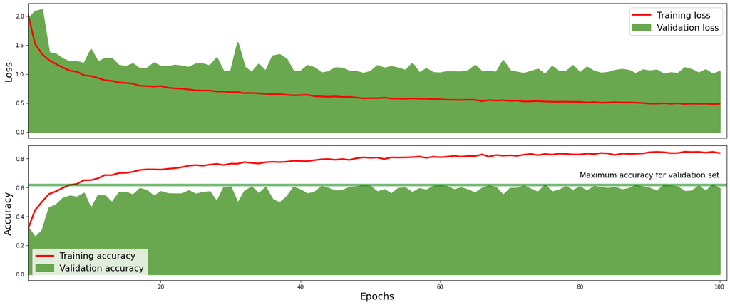

# Testing stage

**Extract** features for test item:

```python
# Get test item
item = db.test(fold=1)[0]

# Extract features
features = mel_extractor.extract(
    AudioContainer().load(filename=item.filename, mono=True)
)[:,:sequence_length]
```

**Reshape** the matrix to match the model input:

```python
input_data = numpy.expand_dims(features, 0)
```

```
input_data shape (sequence, frequency, time):
 (1, 40, 500)
```

Feed input data into the model to get **probabilities for each scene class**:

```python
probabilities = model.predict(x=input_data)
```

```
array([[0.35295883, 0.00327344, 0.00225771, 0.09634162, 0.00080265,
        0.14913237, 0.24045765, 0.14413665, 0.00086025, 0.00977885]],
      dtype=float32)
```

**Classify** by selecting the class giving **maximum output**:

```python
frame_decisions = dcase_util.data.ProbabilityEncoder().binarization(
    probabilities=probabilities.T,
    binarization_type='frame_max'
).T
```

```
array([[1, 0, 0, 0, 0, 0, 0, 0, 0, 0]])
```

Scene label:

```
'airport'
```

# Evaluation

```python
import sklearn

# Get confusion matrix with counts
confusion_matrix = sklearn.metrics.confusion_matrix(y_true, y_pred)

# Transform matrix into percentages, normalize row-wise
conf = confusion_matrix * 100.0 / confusion_matrix.sum(axis=1)[:, numpy.newaxis]

# Fetch class-wise accuracies from diagonal
class_wise_accuracies = numpy.diag(conf)

# Calculate overall accuracy
macro_averaged_accuracy = numpy.mean(class_wise_accuracies)
```

```
Macro-averaged accuracy: 62.5 %
```

## Class-wise accuracies

| Scene label | Accuracy |
| --- | --- |
| airport | 42.3 |
| bus | 66.5 |
| metro | 47.9 |
| metro_station | 53.3 |
| park | 83.1 |
| public_square | 44.0 |
| shopping_mall | 84.6 |
| street_pedestrian | 59.5 |
| street_traffic | 84.6 |
| tram | 59.0 |
| Average | 62.5 |

## Confusion matrix

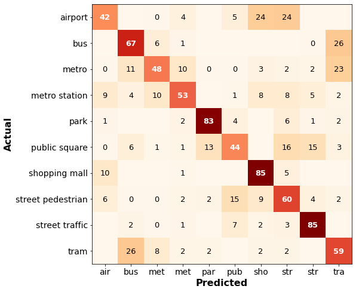

# How to improve:

- Collect **more material**
- Use **data augmentation** to generate more variability in learning examples
- Use **transfer learning** techniques to distill knowledge from other tasks
- Use different **network architectures**